# Trabajo Práctico 2

Estimación de parámetros, correlaciones entre variables, gráficos y pruebas de hipótesis

Martin Arrejin - Pamela Bonadeo - Santiago Grinóvero - Paolo Orundés Cardinali

08/05/2026

# Datos generales

**Maestría en Ciencia de Datos - FCyT - UADER**  
**Seminario 1. Técnicas de Análisis en Ciencias de Datos**  
**Trabajo Práctico 2. Estimación de parámetros. Correlaciones entre variables. Gráficos. Pruebas de Hipótesis.**

**Integrantes:** Martin Arrejin - Pamela Bonadeo - Santiago Grinóvero - Paolo Orundés Cardinali  
**Código en repositorio:** https://github.com/orundescardinalipaolo/cdd

# Introducción

Se trabaja con la base de datos `Student0405.txt`, que contiene datos recolectados durante los años 2004 y 2005 de estudiantes en clases de estadística de una Universidad de Estados Unidos.

Las variables consideradas son: género (`Sex`), promedio de calificaciones (`GPA`), importancia de la religión en sus vidas (`ReligImp`), cantidad de faltas promedio por semana (`MissClass`), ubicación en el aula (`Seat`), días de fiesta en un mes (`PartyDays`) y horas semanales de estudio (`StudyHrs`).

# a) Visualización de la base de datos y variables

La primera alternativa de lectura con `read.table()` produjo un error porque la base está separada por tabulaciones. Por ese motivo se utiliza `read.delim()` indicando `sep = "\t"`.

```r
# Ruta del archivo de datos.
# Si el archivo está dentro de la carpeta seminario1, se usa esa ruta.
# Si está en la misma carpeta del Rmd, se usa Student0405.txt.
ruta_datos <- if (file.exists("seminario1/Student0405.txt")) {
  "seminario1/Student0405.txt"
} else {
  "Student0405.txt"
}

# Carga de datos separados por tabulaciones.
datos <- read.delim(
  ruta_datos,
  sep = "\t",
  header = TRUE,
  strip.white = TRUE,
  na.strings = c("", "NA")
)

# Conversión de variables numéricas.
datos$GPA <- as.numeric(datos$GPA)
datos$MissClass <- as.numeric(datos$MissClass)
datos$PartyDays <- as.numeric(datos$PartyDays)
datos$StudyHrs <- as.numeric(datos$StudyHrs)

# Limpieza de espacios y valores vacíos en Seat.
datos$Seat <- trimws(datos$Seat)
datos$Seat[datos$Seat == ""] <- NA

# Adjuntamos la base de datos.
attach(datos)

# Visualización de estructura y primeros registros.
str(datos)
```

```
## 'data.frame':    690 obs. of  7 variables:
##  $ Sex      : chr  "Female" "Male" "Female" "Female" ...
##  $ GPA      : num  3.7 3.2 3.01 3.77 3.28 2.8 2.5 3.11 3.15 3.44 ...
##  $ ReligImp : chr  "Fairly" "Fairly" "Fairly" "Not" ...
##  $ MissClass: num  1 3 0 0 0 0 3 0 2 0 ...
##  $ Seat     : chr  "Back" "Front" "Middle" "Middle" ...
##  $ PartyDays: num  5 3 8 0 8 2 1 2 15 1 ...
##  $ StudyHrs : num  3 30 16 4 12 20 4 15 7 40 ...
```

```r
head(datos)
```

```
##      Sex  GPA ReligImp MissClass   Seat PartyDays StudyHrs
## 1 Female 3.70   Fairly         1   Back         5        3
## 2   Male 3.20   Fairly         3  Front         3       30
## 3 Female 3.01   Fairly         0 Middle         8       16
## 4 Female 3.77      Not         0 Middle         0        4
## 5   Male 3.28      Not         0 Middle         8       12
## 6 Female 2.80   Fairly         0 Middle         2       20
```

El comando `View(datos)` puede utilizarse en RStudio para abrir la base en una ventana tipo planilla. Se deja indicado, pero no se ejecuta automáticamente al compilar el RMarkdown.

```r
View(datos)
```

## Observaciones de Paolo Orundés Cardinali

La base de datos fue cargada correctamente utilizando `read.delim()`, ya que el archivo se encuentra separado por tabulaciones. Luego se revisó su estructura con `str(datos)` y los primeros registros con `head(datos)`. También se convirtieron las variables numéricas para asegurar que puedan utilizarse en cálculos estadísticos.

# b) Tamaño muestral y cantidad de variables

```r
nrow(datos)   # cantidad de observaciones
```

```
## [1] 690
```

```r
ncol(datos)   # cantidad de variables
```

```
## [1] 7
```

```r
dim(datos)    # filas y columnas
```

```
## [1] 690   7
```

## Observaciones de Paolo Orundés Cardinali

La base contiene 690 observaciones y 7 variables. Por lo tanto, el tamaño muestral es de 690 estudiantes.

# c) Variables cuantitativas y cualitativas

```r
str(datos)
```

```
## 'data.frame':    690 obs. of  7 variables:
##  $ Sex      : chr  "Female" "Male" "Female" "Female" ...
##  $ GPA      : num  3.7 3.2 3.01 3.77 3.28 2.8 2.5 3.11 3.15 3.44 ...
##  $ ReligImp : chr  "Fairly" "Fairly" "Fairly" "Not" ...
##  $ MissClass: num  1 3 0 0 0 0 3 0 2 0 ...
##  $ Seat     : chr  "Back" "Front" "Middle" "Middle" ...
##  $ PartyDays: num  5 3 8 0 8 2 1 2 15 1 ...
##  $ StudyHrs : num  3 30 16 4 12 20 4 15 7 40 ...
```

```r
summary(datos)
```

```
##      Sex                 GPA          ReligImp           MissClass
##  Length:690         Min.   :1.500   Length:690         Min.   :0.0000
##  Class :character   1st Qu.:2.930   Class :character   1st Qu.:0.0000
##  Mode  :character   Median :3.200   Mode  :character   Median :1.0000
##                     Mean   :3.179                      Mean   :0.9086
##                     3rd Qu.:3.515                      3rd Qu.:1.0000
##                     Max.   :4.000                      Max.   :6.0000
##                     NA's   :3                          NA's   :1
##      Seat             PartyDays         StudyHrs
##  Length:690         Min.   : 0.000   Min.   : 0.00
##  Class :character   1st Qu.: 3.000   1st Qu.: 6.25
##  Mode  :character   Median : 7.000   Median :10.00
##                     Mean   : 7.501   Mean   :13.16
##                     3rd Qu.:11.000   3rd Qu.:16.00
##                     Max.   :31.000   Max.   :70.00
##                                      NA's   :4
```

| Variable | Descripción | Tipo |
| --- | --- | --- |
| `Sex` | Género | Cualitativa nominal |
| `GPA` | Promedio de calificaciones | Cuantitativa continua |
| `ReligImp` | Importancia de la religión | Cualitativa ordinal |
| `MissClass` | Faltas promedio por semana | Cuantitativa discreta |
| `Seat` | Ubicación en el aula | Cualitativa nominal |
| `PartyDays` | Días de fiesta en un mes | Cuantitativa discreta |
| `StudyHrs` | Horas semanales de estudio | Cuantitativa discreta o continua, según criterio de registro |

Para identificar las categorías de las variables cualitativas se utilizan tablas de frecuencia.

```r
table(datos$Sex, useNA = "ifany")
```

```
##
## Female   Male
##    382    308
```

```r
table(datos$Seat, useNA = "ifany")
```

```
##
##   Back  Front Middle   <NA>
##    134    151    404      1
```

```r
table(datos$ReligImp, useNA = "ifany")
```

```
##
## Fairly    Not   Very
##    319    222    149
```

## Observaciones de Paolo Orundés Cardinali

Las variables cuantitativas son `GPA`, `MissClass`, `PartyDays` y `StudyHrs`, ya que representan mediciones o conteos numéricos. Entre ellas, `MissClass` y `PartyDays` pueden considerarse discretas porque expresan cantidades contables.

Las variables cualitativas son `Sex`, `Seat` y `ReligImp`. La variable `Sex` clasifica a los estudiantes según género, `Seat` indica la ubicación en el aula y `ReligImp` representa una escala de importancia, por lo que se interpreta como cualitativa ordinal.

Las categorías observadas son las siguientes: en `Sex`, `Female` y `Male`; en `Seat`, `Back`, `Front` y `Middle`; y en `ReligImp`, `Fairly`, `Not` y `Very`.

# d) Resumen numérico y distribución de GPA

```r
resumen_GPA <- data.frame(
  Minimo = min(datos$GPA, na.rm = TRUE),
  Q1 = quantile(datos$GPA, 0.25, na.rm = TRUE),
  Mediana = median(datos$GPA, na.rm = TRUE),
  Media = mean(datos$GPA, na.rm = TRUE),
  Q3 = quantile(datos$GPA, 0.75, na.rm = TRUE),
  Maximo = max(datos$GPA, na.rm = TRUE),
  Desvio_Estandar = sd(datos$GPA, na.rm = TRUE),
  Varianza = var(datos$GPA, na.rm = TRUE)
)

resumen_GPA
```

```
##     Minimo   Q1 Mediana    Media    Q3 Maximo Desvio_Estandar  Varianza
## 25%    1.5 2.93     3.2 3.179214 3.515      4       0.4533599 0.2055352
```

## Histograma

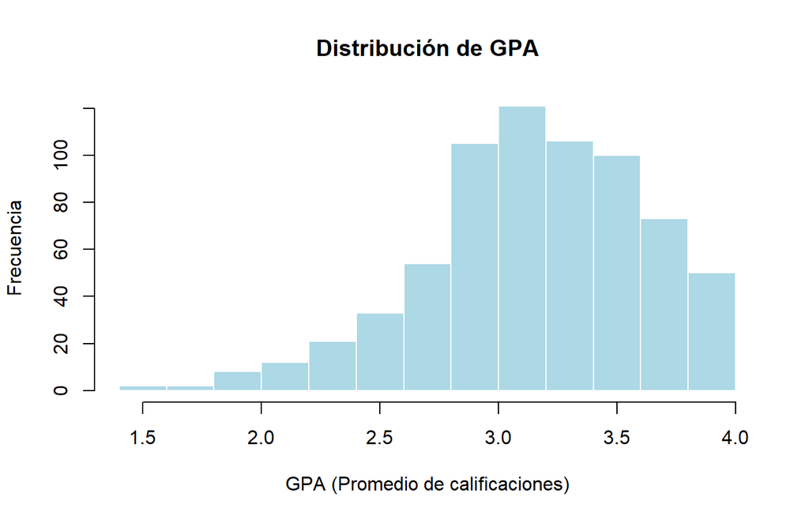

```r
hist(datos$GPA,
     main = "Distribución de GPA",
     xlab = "GPA (Promedio de calificaciones)",
     ylab = "Frecuencia",
     col = "lightblue",
     border = "white")
```

## Boxplot

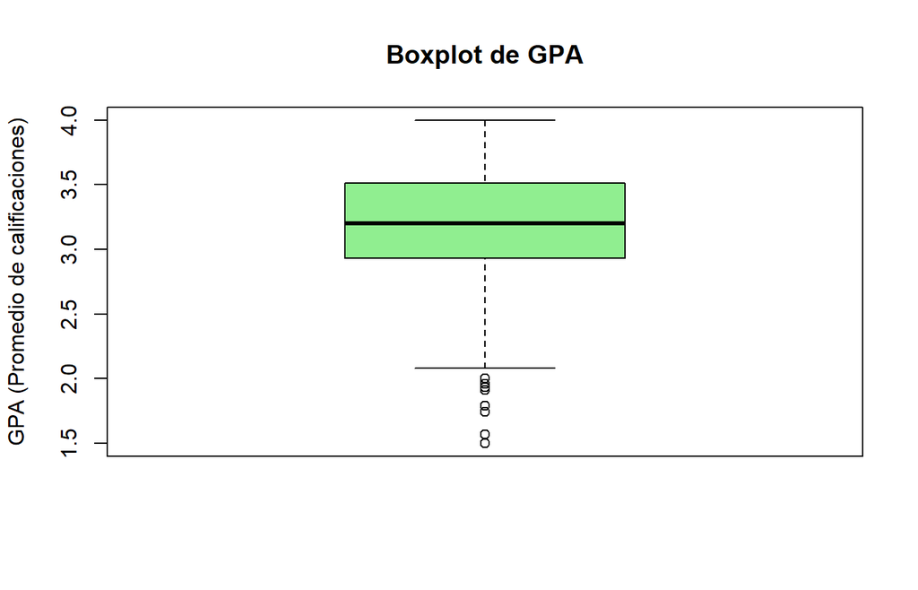

```r
boxplot(datos$GPA,
        main = "Boxplot de GPA",
        ylab = "GPA (Promedio de calificaciones)",
        col = "lightgreen")
```

## Observaciones de Paolo Orundés Cardinali

En el histograma se observa que la variable `GPA` presenta valores concentrados alrededor de la zona central hacia la derecha de la distribución, más precisamente en el rango aproximado entre 2.9 y 3.5.

En el boxplot de `GPA` se observa que la mayoría de las calificaciones se concentran entre aproximadamente 2.9 y 3.5, con una mediana cercana a 3.2. Además, aparecen algunos valores atípicos inferiores, lo que indica que existen pocos estudiantes con `GPA` bastante más bajo que el resto. En general, los datos se concentran en valores medios-altos.

# e) Días de fiesta por mes según género

```r
aggregate(PartyDays ~ Sex, data = datos, summary)
```

```
##      Sex PartyDays.Min. PartyDays.1st Qu. PartyDays.Median PartyDays.Mean
## 1 Female       0.000000          3.000000         6.500000       7.539267
## 2   Male       0.000000          3.000000         7.000000       7.454545
##   PartyDays.3rd Qu. PartyDays.Max.
## 1         12.000000      31.000000
## 2         10.000000      31.000000
```

```r
aggregate(PartyDays ~ Sex, data = datos, mean, na.rm = TRUE)
```

```
##      Sex PartyDays
## 1 Female  7.539267
## 2   Male  7.454545
```

```r
aggregate(PartyDays ~ Sex, data = datos, median, na.rm = TRUE)
```

```
##      Sex PartyDays
## 1 Female       6.5
## 2   Male       7.0
```

```r
aggregate(PartyDays ~ Sex, data = datos, sd, na.rm = TRUE)
```

```
##      Sex PartyDays
## 1 Female  5.458724
## 2   Male  5.454689
```

## Boxplot

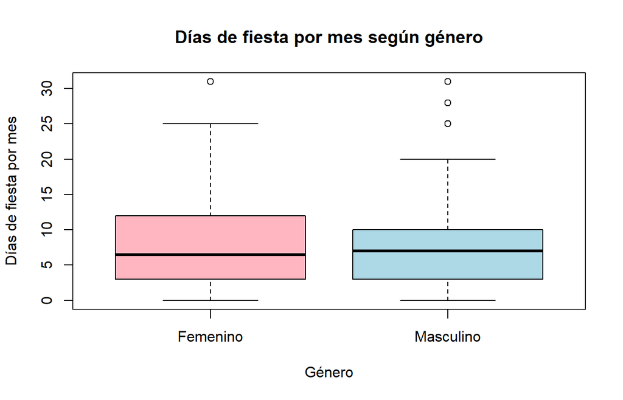

```r
boxplot(PartyDays ~ Sex,
        data = datos,
        main = "Días de fiesta por mes según género",
        xlab = "Género",
        ylab = "Días de fiesta por mes",
        names = c("Femenino", "Masculino"),
        col = c("lightpink", "lightblue"))
```

## Gráfico de barras con promedios

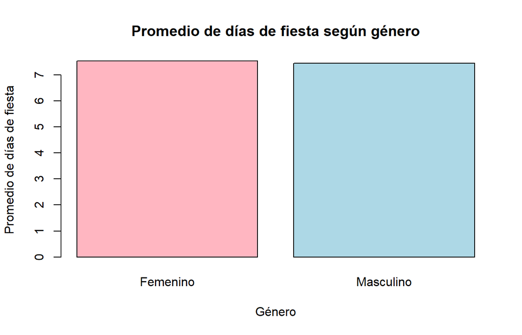

```r
promedios_party <- aggregate(PartyDays ~ Sex, data = datos, mean, na.rm = TRUE)

promedios_party$Genero <- factor(promedios_party$Sex,
                                 levels = c("Female", "Male"),
                                 labels = c("Femenino", "Masculino"))

barplot(promedios_party$PartyDays,
        names.arg = promedios_party$Genero,
        main = "Promedio de días de fiesta según género",
        xlab = "Género",
        ylab = "Promedio de días de fiesta",
        col = c("lightpink", "lightblue"))
```

## Observaciones de Paolo Orundés Cardinali

Para analizar si las mujeres van más a fiestas que los varones, se comparó la variable `PartyDays` según la variable `Sex`. A partir del resumen numérico y del boxplot, no se observan diferencias marcadas entre ambos grupos. La media es apenas superior en el grupo femenino, mientras que la mediana es apenas superior en el grupo masculino.

Por lo tanto, descriptivamente no se puede afirmar una diferencia relevante entre mujeres y varones en la cantidad de días de fiesta por mes. Además, esta observación es descriptiva y no implica por sí sola una diferencia estadísticamente significativa.

# f) GPA según ubicación en el aula

```r
aggregate(GPA ~ Seat, data = datos, summary)
```

```
##     Seat GPA.Min. GPA.1st Qu. GPA.Median GPA.Mean GPA.3rd Qu. GPA.Max.
## 1   Back 1.910000    2.805000   3.100000 3.077015    3.400000 4.000000
## 2  Front 1.740000    3.000000   3.265000 3.251067    3.600000 4.000000
## 3 Middle 1.500000    2.940000   3.205000 3.188781    3.517500 4.000000
```

```r
aggregate(GPA ~ Seat, data = datos, mean, na.rm = TRUE)
```

```
##     Seat      GPA
## 1   Back 3.077015
## 2  Front 3.251067
## 3 Middle 3.188781
```

```r
aggregate(GPA ~ Seat, data = datos, median, na.rm = TRUE)
```

```
##     Seat   GPA
## 1   Back 3.100
## 2  Front 3.265
## 3 Middle 3.205
```

```r
aggregate(GPA ~ Seat, data = datos, sd, na.rm = TRUE)
```

```
##     Seat       GPA
## 1   Back 0.4748027
## 2  Front 0.4486537
## 3 Middle 0.4408886
```

Se verifica si existen valores faltantes en `Seat`.

```r
table(datos$Seat, useNA = "ifany")
```

```
##
##   Back  Front Middle   <NA>
##    134    151    404      1
```

```r
datos[is.na(datos$Seat), ]
```

```
##      Sex  GPA ReligImp MissClass Seat PartyDays StudyHrs
## 305 Male 2.25     Very         1 <NA>         4       10
```

Se crea una base auxiliar excluyendo los casos sin ubicación en aula.

```r
datos_seat <- subset(datos, !is.na(Seat))

aggregate(GPA ~ Seat, data = datos_seat, summary)
```

```
##     Seat GPA.Min. GPA.1st Qu. GPA.Median GPA.Mean GPA.3rd Qu. GPA.Max.
## 1   Back 1.910000    2.805000   3.100000 3.077015    3.400000 4.000000
## 2  Front 1.740000    3.000000   3.265000 3.251067    3.600000 4.000000
## 3 Middle 1.500000    2.940000   3.205000 3.188781    3.517500 4.000000
```

```r
aggregate(GPA ~ Seat, data = datos_seat, mean, na.rm = TRUE)
```

```
##     Seat      GPA
## 1   Back 3.077015
## 2  Front 3.251067
## 3 Middle 3.188781
```

```r
aggregate(GPA ~ Seat, data = datos_seat, sd, na.rm = TRUE)
```

```
##     Seat       GPA
## 1   Back 0.4748027
## 2  Front 0.4486537
## 3 Middle 0.4408886
```

## Boxplot

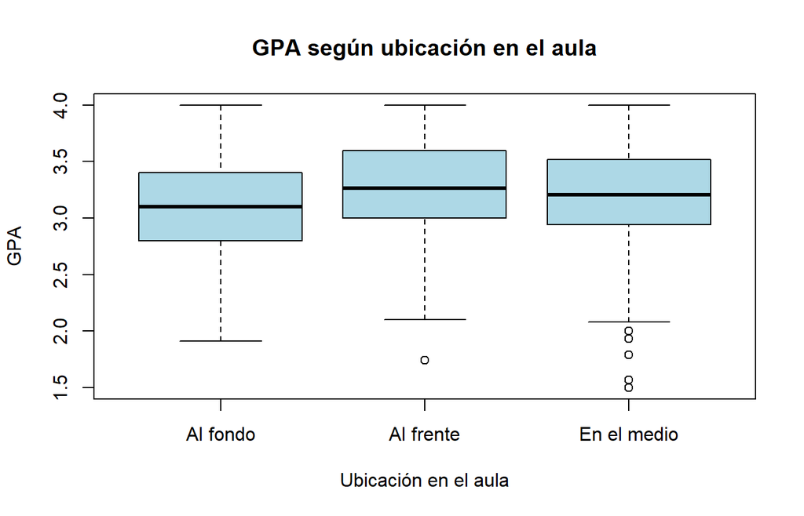

```r
boxplot(GPA ~ Seat,
        data = datos_seat,
        main = "GPA según ubicación en el aula",
        xlab = "Ubicación en el aula",
        ylab = "GPA",
        names = c("Al fondo", "Al frente", "En el medio"),
        col = "lightblue")
```

## Observaciones de Paolo Orundés Cardinali

Al analizar la variable `Seat`, se detectó un registro sin categoría asignada. Dado que no es posible identificar la ubicación del estudiante en el aula, dicho valor se consideró como dato faltante (`NA`) y se excluyó del análisis comparativo de `GPA` según ubicación. Esta decisión evita interpretar erróneamente el valor vacío como una categoría válida.

En el resumen numérico se observa que los estudiantes ubicados al frente presentan el promedio de `GPA` más alto, seguidos por quienes se ubican en el medio y luego por quienes se ubican al fondo. Sin embargo, las diferencias entre los promedios no parecen ser muy marcadas, por lo que descriptivamente no se observa una separación fuerte entre los grupos.

Los puntos inferiores observados especialmente en la categoría “En el medio” representan valores atípicos, es decir, estudiantes con `GPA` más bajo que el resto del grupo.

# g) Frecuencias absolutas y relativas de Seat

```r
freq_abs_seat <- table(datos_seat$Seat)
freq_rel_seat <- prop.table(freq_abs_seat)

tabla_seat <- data.frame(
  Seat = names(freq_abs_seat),
  Frecuencia_Absoluta = as.vector(freq_abs_seat),
  Frecuencia_Relativa = as.vector(freq_rel_seat)
)

tabla_seat$Porcentaje <- tabla_seat$Frecuencia_Relativa * 100

tabla_seat
```

```
##     Seat Frecuencia_Absoluta Frecuencia_Relativa Porcentaje
## 1   Back                 134           0.1944848   19.44848
## 2  Front                 151           0.2191582   21.91582
## 3 Middle                 404           0.5863570   58.63570
```

## Gráfico de barras

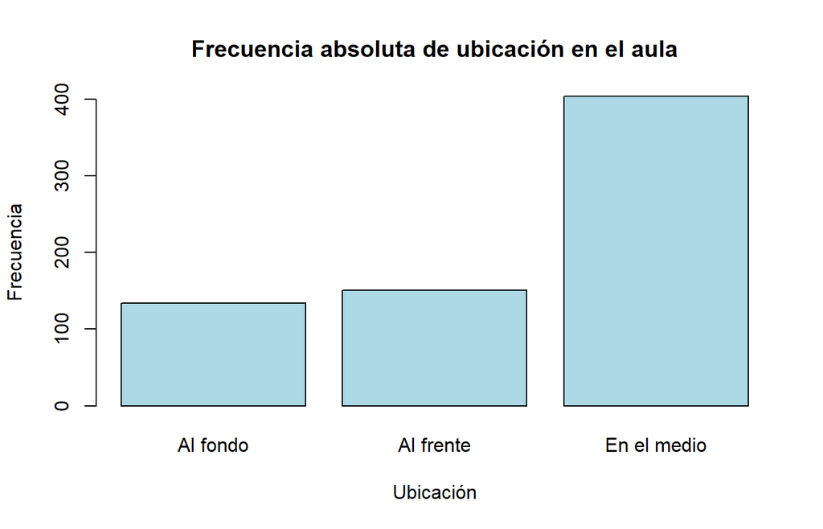

```r
barplot(freq_abs_seat,
        names.arg = c("Al fondo", "Al frente", "En el medio"),
        main = "Frecuencia absoluta de ubicación en el aula",
        xlab = "Ubicación",
        ylab = "Frecuencia",
        col = "lightblue")
```

## Gráfico circular

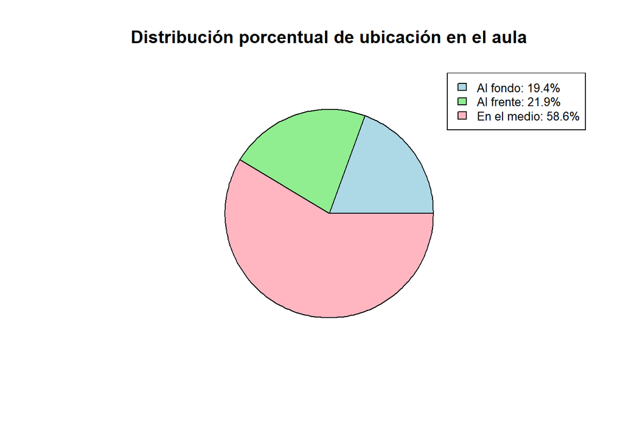

```r
porcentajes_seat <- round(prop.table(freq_abs_seat) * 100, 1)

etiquetas_seat <- paste0(
  c("Al fondo", "Al frente", "En el medio"),
  ": ",
  porcentajes_seat,
  "%"
)

colores_pastel <- c("lightblue", "lightgreen", "lightpink")

pie(freq_abs_seat,
    labels = NA,
    main = "Distribución porcentual de ubicación en el aula",
    col = colores_pastel,
    radius = 0.8)

legend("topright",
       legend = etiquetas_seat,
       fill = colores_pastel,
       cex = 0.8)
```

## Observaciones de Paolo Orundés Cardinali

La variable `Seat` muestra la distribución de los estudiantes según la ubicación que ocupan en el aula. A partir de la tabla de frecuencias absolutas y relativas se puede identificar cuál es la ubicación más frecuente.

Los gráficos permiten visualizar rápidamente si los estudiantes se distribuyen de manera equilibrada entre las categorías o si existe una mayor concentración en alguna ubicación específica. Se observa que las categorías “Al fondo” y “Al frente” tienen una distribución relativamente similar, representando entre ambas alrededor del 40% del total, mientras que casi el 60% de los estudiantes se ubica en el medio del aula.

# h) GPA en función de horas semanales de estudio

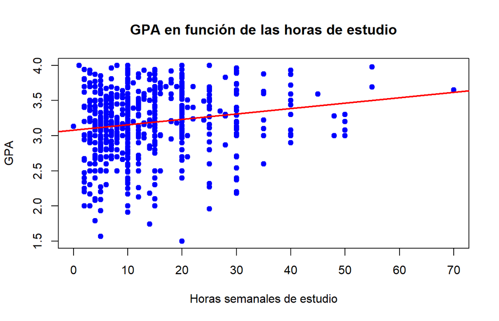

```r
plot(datos$StudyHrs, datos$GPA,
     main = "GPA en función de las horas de estudio",
     xlab = "Horas semanales de estudio",
     ylab = "GPA",
     pch = 19,
     col = "blue")

abline(lm(GPA ~ StudyHrs, data = datos), col = "red", lwd = 2)
```

## Coeficiente de correlación

```r
cor(datos$StudyHrs, datos$GPA, use = "complete.obs")
```

```
## [1] 0.1618092
```

## Observaciones de Paolo Orundés Cardinali

El gráfico muestra una relación positiva débil entre las horas semanales de estudio y el `GPA`. La recta de tendencia tiene una pendiente levemente ascendente, lo que indica que, en general, quienes estudian más horas tienden a tener un `GPA` algo mayor.

Sin embargo, la gran dispersión de los puntos muestra que la relación no es fuerte y que las horas de estudio no explican por sí solas el promedio de calificaciones. El coeficiente de correlación obtenido es cercano a 0, por lo que confirma que la relación lineal entre ambas variables es baja.

# i) GPA en función de horas de estudio, discriminando por sexo

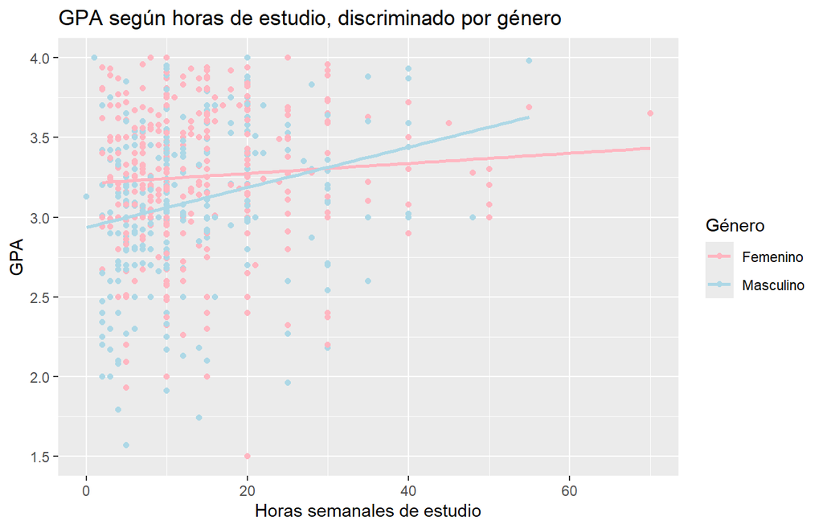

```r
library(ggplot2)

ggplot(datos, aes(x = StudyHrs, y = GPA, color = Sex)) +
  geom_point() +
  geom_smooth(method = "lm", se = FALSE) +
  labs(title = "GPA según horas de estudio, discriminado por género",
       x = "Horas semanales de estudio",
       y = "GPA",
       color = "Género") +
  scale_color_manual(
    values = c("Female" = "lightpink", "Male" = "lightblue"),
    labels = c("Female" = "Femenino", "Male" = "Masculino")
  )
```

## Observaciones de Paolo Orundés Cardinali

Al discriminar por género, se observa que tanto en femenino como en masculino existe una leve tendencia positiva entre horas de estudio y `GPA`. La relación parece algo más marcada en el grupo masculino, aunque en ambos casos los puntos están bastante dispersos. Por lo tanto, no puede afirmarse una relación fuerte entre ambas variables.

# j) Prueba de hipótesis para comparar GPA promedio por género

Como no hay sospechas previas, corresponde una prueba bilateral.

**Hipótesis nula:**  
$H_0$: No existen diferencias entre el promedio de `GPA` de mujeres y varones. Es decir, $\mu_1 = \mu_2$.

**Hipótesis alternativa:**  
$H_1$: Existen diferencias entre el promedio de `GPA` de mujeres y varones. Es decir, $\mu_1 \neq \mu_2$.

## Grupos y resumen por género

```r
table(datos$Sex)
```

```
##
## Female   Male
##    382    308
```

```r
aggregate(GPA ~ Sex, data = datos, mean, na.rm = TRUE)
```

```
##      Sex      GPA
## 1 Female 3.256887
## 2   Male 3.083636
```

```r
aggregate(GPA ~ Sex, data = datos, sd, na.rm = TRUE)
```

```
##      Sex       GPA
## 1 Female 0.4245070
## 2   Male 0.4698712
```

```r
aggregate(GPA ~ Sex, data = datos, length)
```

```
##      Sex GPA
## 1 Female 379
## 2   Male 308
```

Se verifica si existen datos faltantes en `GPA` por género.

```r
table(datos$Sex, is.na(datos$GPA))
```

```
##
##          FALSE TRUE
##   Female   379    3
##   Male     308    0
```

## Normalidad de cada grupo

```r
by(datos$GPA, datos$Sex, function(x) shapiro.test(na.omit(x)))
```

```
## datos$Sex: Female
##
##  Shapiro-Wilk normality test
##
## data:  na.omit(x)
## W = 0.97121, p-value = 7.976e-07
##
## ------------------------------------------------------------
## datos$Sex: Male
##
##  Shapiro-Wilk normality test
##
## data:  na.omit(x)
## W = 0.98234, p-value = 0.0007651
```

## Homogeneidad de varianzas

### Test de Fisher

```r
var.test(GPA ~ Sex, data = datos)
```

```
##
##  F test to compare two variances
##
## data:  GPA by Sex
## F = 0.81623, num df = 378, denom df = 307, p-value = 0.06062
## alternative hypothesis: true ratio of variances is not equal to 1
## 95 percent confidence interval:
##  0.6586425 1.0091053
## sample estimates:
## ratio of variances
##           0.816229
```

### Test de Levene

```r
if (requireNamespace("car", quietly = TRUE)) {
  car::leveneTest(GPA ~ Sex, data = datos)
} else {
  message("El paquete 'car' no está instalado. Instalar con install.packages('car') para ejecutar leveneTest().")
}
```

```
## Levene's Test for Homogeneity of Variance (center = median)
##        Df F value Pr(>F)
## group   1   1.869  0.172
##       685
```

## Prueba t para comparar medias

Dado que el test de Levene no rechaza la igualdad de varianzas, se utiliza la prueba t bilateral con varianzas iguales.

```r
t.test(GPA ~ Sex,
       data = datos,
       alternative = "two.sided",
       var.equal = TRUE)
```

```
##
##  Two Sample t-test
##
## data:  GPA by Sex
## t = 5.0703, df = 685, p-value = 5.119e-07
## alternative hypothesis: true difference in means between group Female and group Male is not equal to 0
## 95 percent confidence interval:
##  0.1061600 0.2403404
## sample estimates:
## mean in group Female   mean in group Male
##             3.256887             3.083636
```

## Observaciones de Paolo Orundés Cardinali

En el grupo femenino se obtuvo un p-value de Shapiro-Wilk menor que 0,05 y en el grupo masculino también se obtuvo un p-value menor que 0,05. Por lo tanto, se rechaza la hipótesis de normalidad en ambos grupos según el test de Shapiro-Wilk.

Para analizar la homogeneidad de varianzas se aplicó el test de Levene. Como el p-value obtenido es mayor que 0,05, no se rechaza la hipótesis de igualdad de varianzas. Por lo tanto, puede considerarse que las varianzas de `GPA` entre mujeres y varones son homogéneas.

Luego se realizó una prueba t bilateral para comparar el promedio de `GPA` entre mujeres y varones. La hipótesis nula plantea que no existen diferencias entre los promedios de ambos grupos, mientras que la hipótesis alternativa plantea que sí existen diferencias.

Dado que el p-value obtenido en la prueba t es menor que 0,05, se rechaza la hipótesis nula. Por lo tanto, se concluye que existen diferencias estadísticamente significativas entre el promedio de `GPA` de mujeres y varones. A partir de los promedios muestrales, se observa que el grupo femenino presenta un `GPA` promedio mayor que el grupo masculino.

Si bien el supuesto de normalidad no se cumple según Shapiro-Wilk, los tamaños muestrales son grandes en ambos grupos, por lo que la prueba t puede considerarse robusta frente a desviaciones de normalidad.

# k) Intervalo de confianza del 98% para la verdadera calificación media

La consigna indica que este intervalo debe calcularse solo si no existen diferencias significativas del promedio de calificaciones según género.

A partir de la prueba t realizada en el inciso j), se obtuvo un p-value menor que 0,05. Por lo tanto, se concluyó que existen diferencias estadísticamente significativas entre los promedios de `GPA` de mujeres y varones.

## Observaciones de Paolo Orundés Cardinali

No se desarrolla el cálculo de un intervalo de confianza general, dado que la condición inicial no se cumple. La prueba t realizada en el inciso j) mostró diferencias significativas entre los promedios de `GPA` según género. Por ello, no resulta adecuado estimar una única media poblacional para todos los estudiantes sin distinguir entre mujeres y varones.

Como aclaración metodológica, si se quisieran estimar intervalos de confianza del 98% considerando la diferencia encontrada por género, lo más adecuado sería calcularlos por separado para cada grupo.

```r
# IC del 98% para GPA en mujeres
t.test(na.omit(datos$GPA[datos$Sex == "Female"]),
       conf.level = 0.98)
```

```
##
##  One Sample t-test
##
## data:  na.omit(datos$GPA[datos$Sex == "Female"])
## t = 149.36, df = 378, p-value < 2.2e-16
## alternative hypothesis: true mean is not equal to 0
## 98 percent confidence interval:
##  3.205943 3.307830
## sample estimates:
## mean of x
##  3.256887
```

```r
# IC del 98% para GPA en varones
t.test(na.omit(datos$GPA[datos$Sex == "Male"]),
       conf.level = 0.98)
```

```
##
##  One Sample t-test
##
## data:  na.omit(datos$GPA[datos$Sex == "Male"])
## t = 115.18, df = 307, p-value < 2.2e-16
## alternative hypothesis: true mean is not equal to 0
## 98 percent confidence interval:
##  3.021025 3.146247
## sample estimates:
## mean of x
##  3.083636
```

También se puede realizar con `by()`.

```r
by(datos$GPA, datos$Sex, function(x) {
  t.test(na.omit(x), conf.level = 0.98)
})
```

```
## datos$Sex: Female
##
##  One Sample t-test
##
## data:  na.omit(x)
## t = 149.36, df = 378, p-value < 2.2e-16
## alternative hypothesis: true mean is not equal to 0
## 98 percent confidence interval:
##  3.205943 3.307830
## sample estimates:
## mean of x
##  3.256887
##
## ------------------------------------------------------------
## datos$Sex: Male
##
##  One Sample t-test
##
## data:  na.omit(x)
## t = 115.18, df = 307, p-value < 2.2e-16
## alternative hypothesis: true mean is not equal to 0
## 98 percent confidence interval:
##  3.021025 3.146247
## sample estimates:
## mean of x
##  3.083636
```